# Fluctuations

**NOTE**: The present notebook is coded in R. It relies heavily on the [**tidyverse**](https://www.tidyverse.org/) ecosystem of packages. We load the tidyverse below as a prerequisite for the rest of the notebook - along with a few other libraries.

$\rightarrow$ Don’t forget that code flows **sequentially**. A random chunk may not work if the previous have have not been executed.

```r
library(tidyverse)   # Package for data wrangling
library(readxl)      # Package to import MS Excel files
library(latex2exp)   # Package for LaTeX expressions
library(quantmod)    # Package for stock data extraction
library(highcharter) # Package for reactive plots
library(WDI)         # Package for World Bank data
library(ggsci)       # Package for color palettes
```

The content of the notebook is heavily inspired from the book [**Advanced Macro-economics - An Easy Guide**](https://press.lse.ac.uk/site/books/m/10.31389/lsepress.ame/).

# Context

Until now, we have mostly been working on **equilibrium** models that are supposed to characterize **long-term** trends (e.g., growth). But, “in practice”, all economic indicators fluctuate, and in some cases, sharp variations occurs, for instance during crises.

So studying the short-term evolution of the economy is also useful (some could suggest it is even more useful!).

Let’s illustrate this rapidly with some data.

```r
wb_raw = WDI(indicator = c("gdp_per_capita" = "NY.GDP.PCAP.KD",
                           "population" = "SP.POP.TOTL",
                           "gdp" = "NY.GDP.MKTP.CD",
                           "consumption" = "NE.CON.TOTL.CD",
                           "gdp_growth" = "NY.GDP.MKTP.KD.ZG",
                           "unemployment" = "SL.UEM.TOTL.ZS"),
             #country = c('FR','US'), # here you can specify some countries
             extra = TRUE,
             start = 1960,
             end = 2025) |>
  mutate(across(everything(), as.vector)) |>
  select(-status, -lending, -iso2c, -iso3c)
wb_data <- wb_raw |> filter(country %in% c("France", "United States")) |> arrange(country, year)
wb_eu <- wb_raw |>
  filter(country %in% c("Spain", "Italy", "Poland", "Slovenia", "Venezuela, RB")) |>
  arrange(country, year)
```

Let us depict the growth rate of the **world’s GDP**.

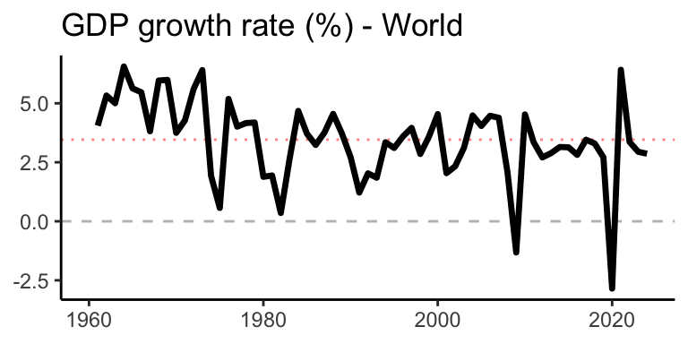

```r
wb_raw |>
  filter(country == "World") |>
  ggplot(aes(x = year, y = gdp_growth)) + geom_hline(yintercept = 0, linetype = 2, color = "gray") +
  geom_hline(yintercept = 3.46, linetype = 3, color = "red", alpha = 0.5) +  # Sample average
  geom_line(linewidth = 1.2) +
  ggtitle("GDP growth rate (%) - World") +
  theme_classic() +
  theme(axis.title = element_blank())
```

Same for **unemployment**… in the US.  
Worldwide, things are much **smoother** (aggregation effect, perhaps!).

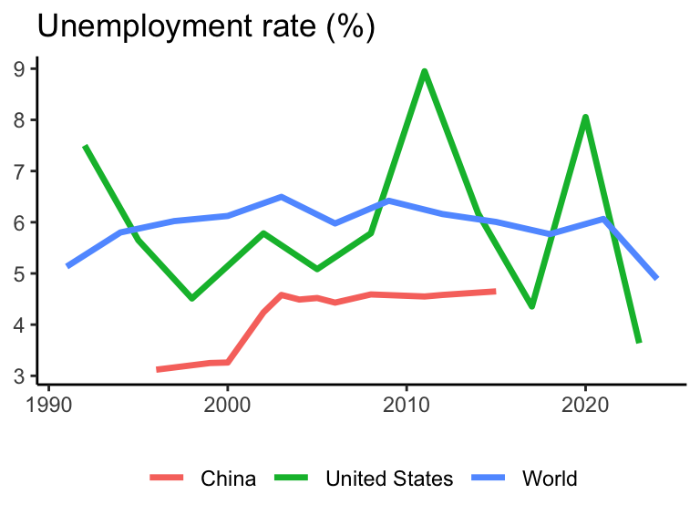

```r
wb_raw |>
  filter(country == c("World", "United States", "China"), year > 1990) |>
  ggplot(aes(x = year, y = unemployment, color = country)) +
  geom_line(linewidth = 1.2) +
  theme_classic() +
  ggtitle("Unemployment rate (%)") +
  theme(axis.title = element_blank(),
        legend.title = element_blank(),
        legend.position = "bottom")
```

# Real business cycle (RBC) models

**NoteWe extend the [**Ramsey model**](https://www.gcoqueret.com/files/macro/S03_Ramsey.html) in two directions:**

- Following [Time to Build and Aggregate Fluctuations](https://www.jstor.org/stable/1913386?seq=15), we assume that the representative agent can choose between working and **leisure time**. Working provides **labor** $l_t$, whereas **leisure** is denoted $h_t$. Because time is limited (it is impossible to increase $l_t$ and $h_t$ indefinitely), we introduce the (normalizing) constraint
  $$l_t+h_t=1.$$
  Here for instance, one means “one day awake”. So let’s say 16 hours: this could mean 8+8, meaning $l_t=h_t=0.5$.
- We assume that, in the **production function** $y_t = z_tk_t^\alpha l_t^{1-\alpha}$, the productivity factor is subject to **shocks** which will generate fluctuations:
  $$z_t = \phi z_{t-1}+e_t, \quad |\phi|<1,$$
  $e_t$ representing iid shocks.

We moreover posit that the agent owns the capital $k_t$ and rents it to the firm at rate $r_t$, so that the budget constraint reads:
$$k_{t+1} = l_tw_t + (1+r_t)k_t-c_t,$$

i.e., future available capital will be the proceeds of investment in prior capital (net of depreciation) plus **income from working** ($w_t$ is the wage) minus **consumption**.

The **utility** of the agent is
$$U=\sum_{t=0}^\infty (1+\rho)^{-t}\left((1-\psi)u(c_t) + \psi v(h_t) \right),$$
where $\psi$ determines the relative importance of work versus leisure (and $\rho$ the time preferences).

The trade-off between leisure and work is obtained by seeing that
$$c_t = w_t(1-h_t) + (1+r_t)k_t-c_t-k_{t+1},$$
and plugging this in the utility and differentiating w.r.t. $h_t$ leads to
$$w_t(1-\psi)u'(c_t)=\psi v'(h_t),$$
so that if we assume **log-utility**,
$$w_t(1-\psi)h_t=\psi c_t.$$

We recall the **Euler equation**:
$$u'(c_t) = \frac{1+r_{t}}{1+\rho} \mathbb{E}_t[u'(c_{t+1})],$$
which, under **logarithmic utility** (again) gives

$$c_t^{-1} = \frac{1+r_{t}}{1+\rho} \mathbb{E}_t[c_{t+1}^{-1}],$$

though, as we will see in the data, in this case the autoregressive parameter should be larger than one (consumption grows steadily). One corollary is that we cannot estimate an AR(1) process for this. Time is relatively finite, there will be no “explosion”.

# Digressions via ILO data

## Data (working hours)

We exploit amazing data from the [ILO](https://ilostat.ilo.org/topics/working-time/) on **working hours**.

The data is highly granular sector-wise and by age but we focus on the economy as a whole and not on particular industries or age groups (for simplicity).

```r
url <- "https://rplumber.ilo.org/data/indicator/?id=HOW_TEMP_SEX_AGE_ECO_NB_A&lang=en&type=label&format=.csv&channel=ilostat&title=mean-weekly-hours-actually-worked-per-employed-person-by-sex-age-and-economic-activity-annual"
ilo_hours <- read_csv(url) |>
  filter(classif2.label == "Economic activity (Broad sector): Total",
         classif1.label == "Age (Aggregate bands): Total") |>
  select(ref_area.label, sex.label, time, obs_value)
colnames(ilo_hours) <- c("country", "gender", "year", "value")
```

Values for **gender**: Total, Male, Female, Other.

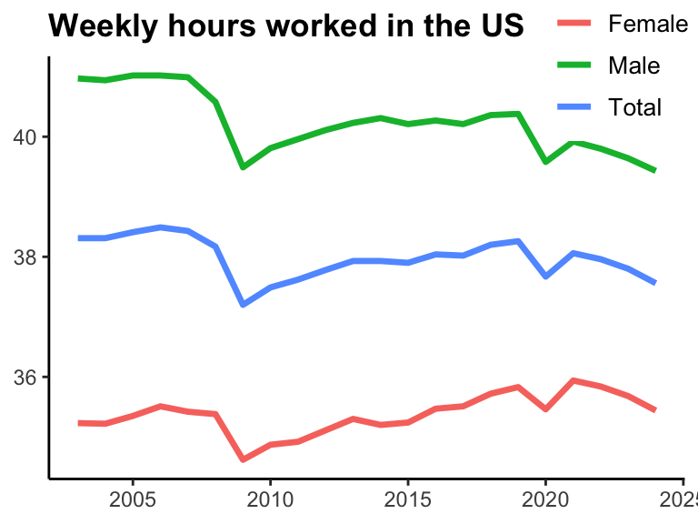

```r
ilo_hours |>
  filter(gender != "Other", country == "United States of America") |>
  ggplot(aes(x = year, y = value, color = gender)) + geom_line(linewidth = 1.2) +
  theme_classic() +
  ggtitle("Weekly hours worked in the US") +
  theme(legend.position = c(0.9, 0.98),
        axis.title = element_blank(),
        title = element_text(face = "bold"),
        legend.text = element_text(size = 10),
        legend.title = element_blank())
```

## Data (wages)

Average hourly earnings of employees (local currency).

```r
url <- "https://rplumber.ilo.org/data/indicator/?id=SDG_0851_SEX_OCU_NB_A&lang=en&type=label&format=.csv&channel=ilostat&title=sdg-indicator-851-average-hourly-earnings-of-employees-by-sex-local-currency-annual"
ilo_wages <- read_csv(url) |>
  select(ref_area.label, sex.label, classif1.label, time, obs_value)
colnames(ilo_wages) <- c("country", "gender", "occupation", "year", "value")
```

We can directly see tne **gender gap**.

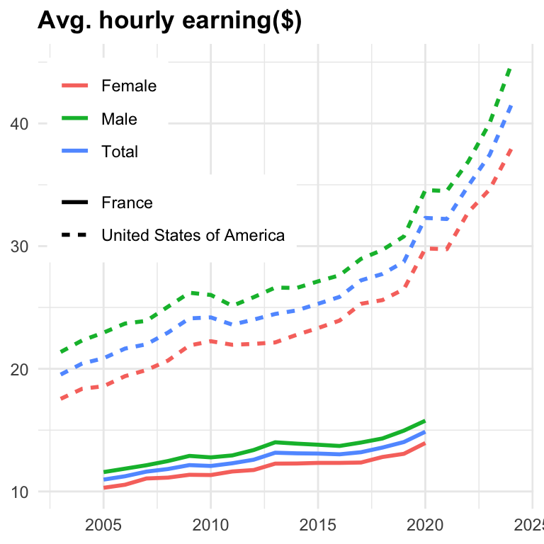

```r
ilo_wages |>
  filter(country %in% c("United States of America", "France"),
         occupation == "Occupation (Skill level): Total") |>
  ggplot(aes(x = year, y = value, color = gender, linetype = country)) +
  geom_line(linewidth = 1.0) +
  theme_minimal() + ggtitle("Avg. hourly earning($)") +
  theme(axis.title = element_blank(),
        legend.title = element_blank(),
        title = element_text(face = "bold"),
        legend.spacing.y = unit(-1, "pt"),
        legend.background = element_rect(fill = "white", color = "white"),
        legend.position = c(0.27, 0.75))
```

## Calibration

Thanks to World Bank data, we can try to estimate some of these quantities.  
For instance, for the volatility of consumption… or its shocks.

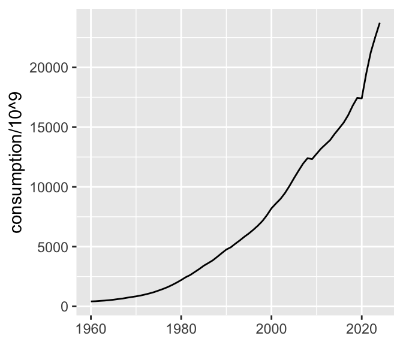

```r
wb_data |>
   filter(country == "United States") |>
  ggplot(aes(x = year, y = consumption/10^9)) + geom_line() +
  theme(axis.title.x = element_blank())
```

```r
wb_data |>
   filter(country == "United States") |>
   mutate(c_growth = consumption/dplyr::lag(consumption) - 1) |>
   summarise(m = mean(c_growth, na.rm = T),
             s = sd(c_growth, na.rm = T))
```

| m | s |
| --- | --- |
| 0.0655962 | 0.0275734 |

So consumption grows at a rate of 6.5% per year with a 2.8% standard deviation for its growth.

# Simulations

Below, we assume fixed $r_t$ for simplicity (which drives consumption and capital dynamics), as well as exogenous wages $w_t=e^{r_wt}$ following deterministic inflation. We start by setting the parameters and initializing the variables. Note that we impose $(1+r)/(1+\rho)\approx 1.06$.

```r
rho <- 0.01       # Discounting factor
sigma_c <- 0.03   # Vol of consumption innovations
sigma_A <- 0.005  # Vol of TPF schocks
psi <- 0.5        # Relative work/leisure preference
phi <- 0.003      # Growth rate of TPF
r <- 0.07         # Interest rate
r_w <- 0.06       # Growth rate of wages

n <- 100          # Number of periods
z <- 1            # Initialization of productivity
c <- 1            # Initialization of consumption
w <- 5            # Initialization of wages
k <- 6            # Initialization of capital
h <- 0.5          # Initialization of leisure
```

Next, we launch the loop and plot the resulting time-series.

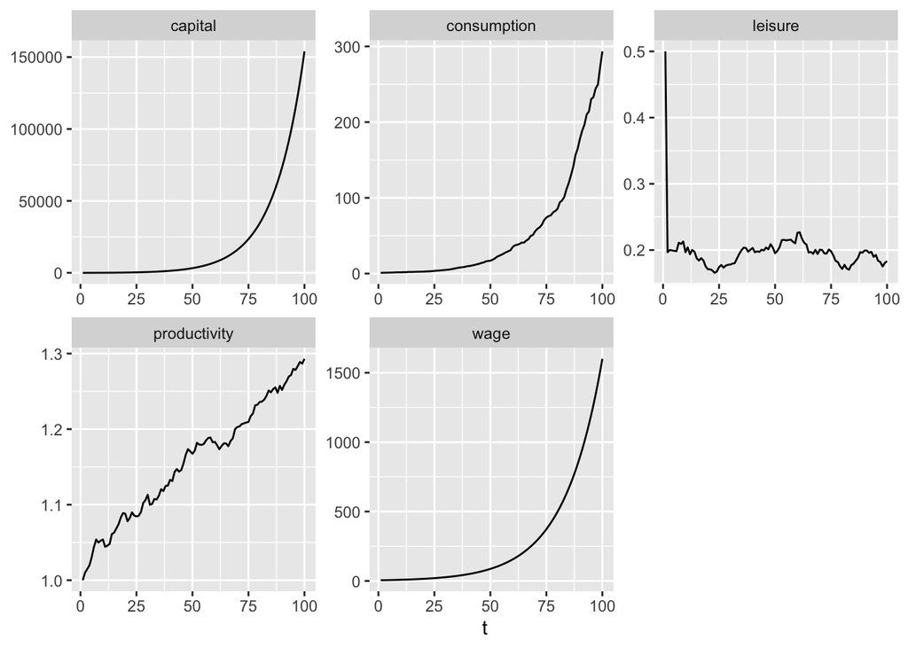

```r
set.seed(42)
for(t in 1:(n-1)){
  w[t+1] <- (1+r_w) * w[t]                                # Deterministic wages
  z[t+1] <- (1+phi + sigma_A * rnorm(1)) * z[t]             # Productivity shock
  c[t+1] <- ((1+r)/(1+rho) + sigma_c * rnorm(1)) * c[t]   # Consumption with shock
  h[t+1] <- psi/(1-psi)*c[t+1]/w[t+1]                     # Leisure from log-utility
  k[t+1] <- (1-h[t])*w[t] + (1+r)*k[t] - c[t]             # Motion of capital
}
data.frame(t = 1:n, wage = w, productivity = z, consumption = c, leisure = h, capital = k) |>
  pivot_longer(-t, names_to = "variable", values_to = "value") |>
  ggplot(aes(x = t, y = value)) + geom_line() +
  facet_wrap(vars(variable), scales = "free") +
  theme(axis.title.y = element_blank())
```

This can seem a bit simplistic, but some matches a few patterns in the data.  
For **productivity**, the trend is exactly that from the data (makes sense), but for the relative importance of **leisure**, it’s hard to tell.  
Maybe the model could serve as a tool to determine reasonable values for $l$!

# Keynesian models

**TipHonest disclaimer**

This subsection was *partly* generated by generative AI.

## Introduction to IS-LM

### 1️⃣ The IS Curve — *Goods Market Equilibrium*

The **IS equation** is
$$Y = C(Y - T) + I(i) + G + NX.$$

The interpretation is as follows. Total **output (Y)** equals **total planned spending** (aggregate demand):

- $C(Y - T)$: **consumption** by households (depends positively on disposable income, minus taxes);
- $I(i)$: **investment** by firms (depends *negatively* on the interest rate);
- $G$: government **spending** (exogenous);
- $NX$: net **exports** (exports minus imports).

This is the GDP [**expenditure approach/decomposition**](https://en.wikipedia.org/wiki/Gross_domestic_product#Expenditure_approach) which we have briefly mentioned earlier. Mechanically,

- When the **interest rate** ($i$) falls → investment ($I$) rises → total demand increases → output ($Y$) rises.
- When the **interest rate** rises → investment falls → demand and output fall.

Hence, the IS curve shows an **inverse relationship** between ($i$) and ($Y$): it is **downward sloping** in the ($Y$, $i$) plane.

**NoteWhy “IS”?**

It stands for **Investment = Saving**: every point on the curve represents equilibrium in the **goods market**.

### 2️⃣ The LM Curve — *Money Market Equilibrium*

The **LM Equation** is

$$\frac{M}{P} = L(i, Y)$$

Equilibrium in the **money market** occurs when:

- $M/P$: **real money supply** (nominal supply set by the central bank, adjusted for prices to take inflation into account; $P$ is a proxy for the aggregate price level);
- $L(i, Y)$: **money demand** (desired amount of purchasing power that agents wish to hold in liquid form), which is a function that:
  - increases with $Y$ (more income → more transactions),
  - decreases with $i$ (higher interest rates → less willingness to hold money).

The implications:

- When **income** ($Y$) rises → people want more money for transactions.  
  Since the real money supply $M/P$ is fixed, the **interest rate** ($i$) must rise to restore equilibrium.
- Therefore, the LM curve shows a **positive relationship** between $Y$ and $i$:  
  it is **upward sloping** in the $(Y, i)$ plane.

**NoteWhy “LM”?**

It stands for **Liquidity preference = Money supply**, i.e., points where the **money market is in equilibrium**.

### 3️⃣ The IS–LM Intersection — *General Equilibrium*

At the intersection of IS and LM, we obtain: $(Y^*, i^*)$:

- $Y^*$: equilibrium output (goods market equilibrium)
- $i^*$: equilibrium interest rate (money market equilibrium)

#### Interpretation

At this point, **both markets clear**:

- The **goods market** is in equilibrium (aggregate demand = output).
- The **money market** is in equilibrium (money supply = money demand).

### 🧭 A few policy implications

- **Fiscal policy for the government** (↑$G$ or ↓$T$) → shifts **IS** to the right → higher $Y$, higher $i$.
- **Monetary policy for the central bank** (↑$M$) → shifts **LM** to the right → higher $Y$, lower $i$.

Thus, policymakers can influence short-run output and interest rates through **fiscal and monetary actions**.  
Clear examples of this with the FED that micro-tunes interest rates to keep the economy in balance (not heating and out of recession). But with dual objectives on **inflation** and **unemployment**…

### Code

We use linear forms for simplicity:

- **IS**: $i = a - b \times Y$
- **LM**: $i = c + d \times Y$

First, the parameters and the generation of data (code on the right).

```r
# Parameters
a <- 12      # IS intercept
b <- 0.8     # IS slope
c <- 2       # LM intercept
d <- 0.3     # LM slope

# Range of Y (output)
Y_seq <- seq(0, 20, length.out = 200)

# IS and LM curves
data <- data.frame(
  Y = Y_seq,
  IS = a - b * Y_seq,
  LM = c + d * Y_seq
)

# Compute equilibrium (intersection point) --------------------------------
# a - bY = c + dY  =>  Y* = (a - c)/(b + d)
Y_eq <- (a - c) / (b + d)
i_eq <- a - b * Y_eq
```

Then, the plot.

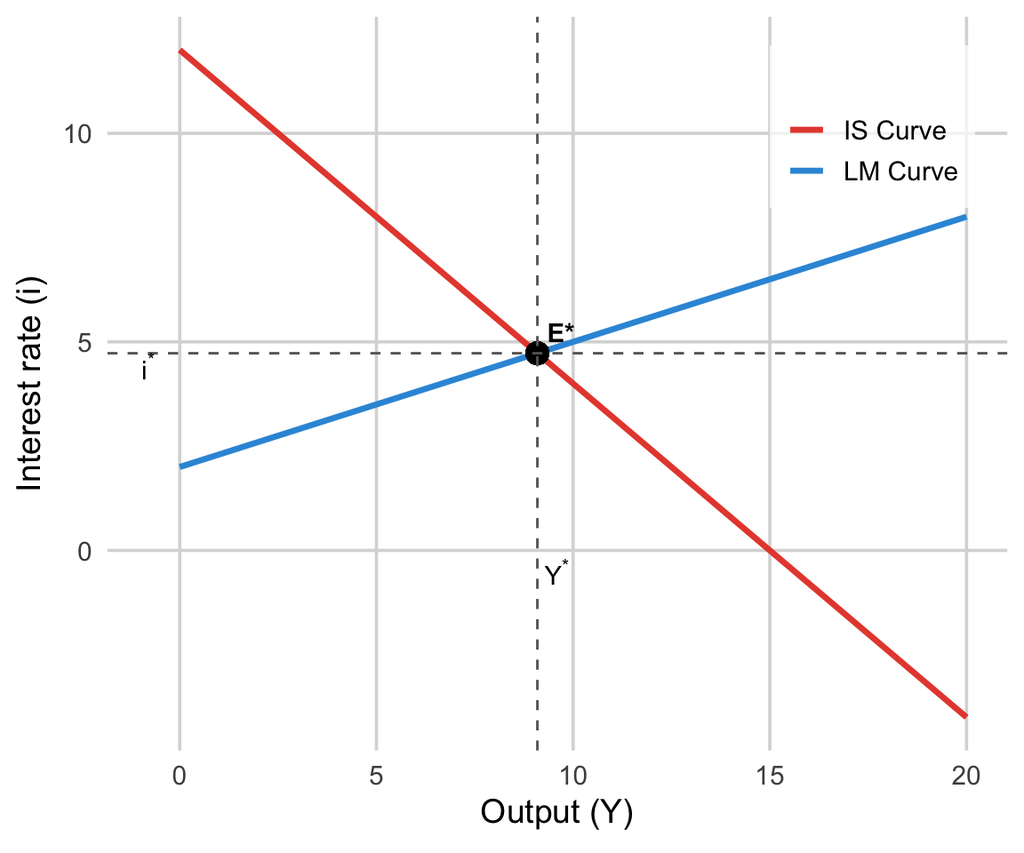

```r
ggplot(data, aes(x = Y)) +
  # Curves
  geom_line(aes(y = IS, color = "IS Curve"), size = 1.2, linetype = "solid") +
  geom_line(aes(y = LM, color = "LM Curve"), size = 1.2, linetype = "solid") +
  # Equilibrium point
  geom_point(aes(x = Y_eq, y = i_eq), size = 4, color = "black") +
  geom_vline(xintercept = Y_eq, linetype = "dashed", color = "gray40") +
  geom_hline(yintercept = i_eq, linetype = "dashed", color = "gray40") +
  # Labels for equilibrium
  annotate("text", x = Y_eq + 0.6, y = i_eq + 0.5, label = "E*", fontface = "bold") +
  annotate("text", x = Y_eq + 0.5, y = -0.5, label = expression(Y^"*"), parse = TRUE) +
  annotate("text", x = -0.8, y = i_eq - 0.3, label = expression(i^"*"), parse = TRUE) +
  # Axes labels
  labs(x = expression("Output (Y)"), y = expression("Interest rate (i)"), color = "") +
  # Colors & theme
  scale_color_manual(values = c("IS Curve" = "#E74C3C", "LM Curve" = "#3498DB")) +
  theme_minimal(base_size = 14) +
  theme(
    legend.position = c(0.85, 0.85),
    legend.background = element_rect(fill = alpha("white", 0.7), color = NA),
    panel.grid.minor = element_blank(),
    panel.grid.major = element_line(color = "gray85")
  )
```

What happens when a **policy change** occurs?

```r
# Original curves:
a  <- 12    # IS intercept
b  <- 0.8   # IS slope
c  <- 2     # LM intercept
d  <- 0.3   # LM slope
# Policy-shifted curves:
a_shift <- 14   # Fiscal expansion -> IS shifts right (higher intercept)
c_shift <- 1    # Monetary expansion -> LM shifts down (lower intercept)
Y_seq <- seq(0, 20, length.out = 200)
# --- 2. Compute curves -----------------------------------------------------
data <- data.frame(
  Y = Y_seq,
  IS_orig = a - b * Y_seq,
  IS_new  = a_shift - b * Y_seq,
  LM_orig = c + d * Y_seq,
  LM_new  = c_shift + d * Y_seq
)
# --- 3. Compute equilibria -------------------------------------------------
# Original equilibrium
Y_eq_orig <- (a - c) / (b + d)
i_eq_orig <- a - b * Y_eq_orig
# New equilibrium (after both shifts)
Y_eq_new <- (a_shift - c_shift) / (b + d)
i_eq_new <- a_shift - b * Y_eq_new
```

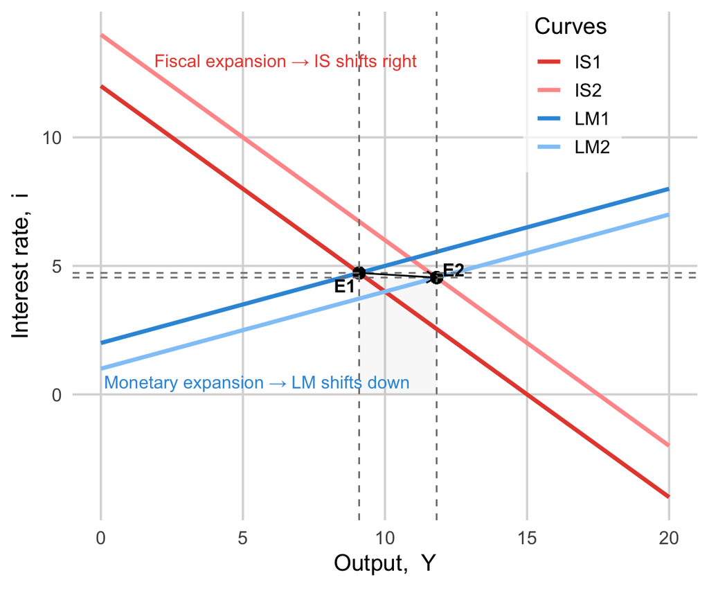

```r
# --- 4. Build plot ---------------------------------------------------------
ggplot(data, aes(x = Y)) +
  # Shaded regions to highlight movement
  annotate("rect", xmin = Y_eq_orig, xmax = Y_eq_new,
           ymin = 0, ymax = i_eq_new, alpha = 0.05, fill = "gray50") +
  # IS curves
  geom_line(aes(y = IS_orig, color = "IS1"), size = 1.2) +
  geom_line(aes(y = IS_new, color = "IS2"), size = 1.2, linetype = "solid") +
  # LM curves
  geom_line(aes(y = LM_orig, color = "LM1"), size = 1.2) +
  geom_line(aes(y = LM_new, color = "LM2"), size = 1.2, linetype = "solid") +
  # Equilibria
  geom_point(aes(x = Y_eq_orig, y = i_eq_orig), size = 3, color = "black") +
  geom_point(aes(x = Y_eq_new, y = i_eq_new), size = 3, color = "black") +
  # Dashed lines for equilibrium coordinates
  geom_vline(xintercept = c(Y_eq_orig, Y_eq_new), linetype = "dashed", color = "gray50") +
  geom_hline(yintercept = c(i_eq_orig, i_eq_new), linetype = "dashed", color = "gray50") +
  # Labels for equilibria
  annotate("text", x = Y_eq_orig - 0.5, y = i_eq_orig - 0.5, label = "E1", fontface = "bold") +
  annotate("text", x = Y_eq_new + 0.6, y = i_eq_new + 0.3, label = "E2", fontface = "bold") +
  # Arrows showing movement
  annotate("segment",
           x = Y_eq_orig , xend = Y_eq_new ,
           y = i_eq_orig , yend = i_eq_new ,
           color = "black", arrow = arrow(length = unit(0.25, "cm"))) +
  labs(x = expression("Output, " ~ Y), y = expression("Interest rate, " ~ i), color = "Curves") +
  scale_color_manual(values = c(
    "IS1" = "#E74C3C",   # red
    "IS2" = "#FF9999",   # lighter red
    "LM1" = "#3498DB",   # blue
    "LM2" = "#91C9F7"    # lighter blue
  )) +
  theme_minimal(base_size = 14) +
  theme(
    legend.position = c(0.8, 0.85),
    legend.background = element_rect(fill = alpha("white", 0.7), color = NA),
    panel.grid.minor = element_blank(),
    panel.grid.major = element_line(color = "gray85")
  ) +
  # Annotations for policy
  annotate("text", x = 6.5, y = 13, label = "Fiscal expansion → IS shifts right", color = "#E74C3C", size = 3.8) +
  annotate("text", x = 5.5, y = 0.5, label = "Monetary expansion → LM shifts down", color = "#3498DB", size = 3.8)
```

When both shifts occur at the same time, the new equilibrium is favorable to growth, but mixed for interest rates (opposite effects).

## The Taylor rule

The [**Taylor Rule**](https://en.wikipedia.org/wiki/Taylor_rule) is a simple yet powerful guideline for how a **central bank** (like the Federal Reserve or the European Central Bank) should **set its short-term nominal interest rate** in response to changes in **inflation** and **economic activity**.

It was introduced by economist John B. Taylor (in 1992) as a way to describe and formalize the behavior of monetary policy under an **inflation-targeting framework**.

**NoteThe equation**

$$i_t = r^* + \pi_t + \phi_{\pi} (\pi_t - \pi^*) + \phi_{y} (y_t - \bar{y}_t)$$

Where:

- $i_t$: **nominal policy interest rate** (e.g., the federal funds rate) $\rightarrow$ the instrument
- $r^*$: **equilibrium real interest rate** (neutral rate consistent with full employment)
- $\pi_t$: **current inflation rate**
- $\pi^*$: **target inflation rate**
- $y_t - \bar{y}_t$: **output gap** (actual output minus potential output)
- $\phi_{\pi}, \phi_{y}$: policy response coefficients to inflation and output, respectively

We clearly see the **dual objective** of the FED here: balancing inflation & growth (and implicitly, tackling unemployment, too).

### Economic Intuition

- When **inflation** is **above target** ($\pi_t > \pi^*$), the rule recommends **raising** the policy rate.
- When **output** is **below potential** ($y_t < \bar{y}_t$), it suggests **lowering** the policy rate to stimulate the economy.
- The Taylor Rule thus balances the central bank’s **dual mandate**:
  - price stability (control inflation), and
  - economic stability (support output and employment).

### Example (Typical Parameterization)

A commonly used version is:

$$i_t = r^* + \pi_t + 0.5 \times (\pi_t - \pi^*) + 0.5 \times (y_t - \bar{y}_t)$$

This means the central bank raises the nominal rate by **0.5 percentage points** for each **1-point rise in inflation** above target and by **0.5 points** for each **1-point rise in the output gap**.

Let’s take values that reflect historical patterns (2010-2025). For instance, $r^*=2\%$, $\pi= 2.5\%$, $\pi^*=2\%$, $\bar{y}=1.5\%$, $y=1\%$. Then,
$$i_t = 2\% + 2.5\% + 0.5 \times (0.5\%) + 0.5 \times (-0.5\%)= 4.5\%$$

and this is not too far from the [**FED rate**](https://fred.stlouisfed.org/series/FEDFUNDS) as of late 2025.

For Europe, see the [**ECB portal**](https://data.ecb.europa.eu/main-figures/ecb-interest-rates-and-exchange-rates/key-ecb-interest-rates).

### Relation to IS–LM and Modern Policy

In the **IS–LM framework**, the Taylor Rule replaces the **exogenous LM curve** with an **interest-rate rule** that depends on inflation and output.  
This leads to the **New Keynesian IS–MP model**, where monetary policy (MP curve) is **explicitly governed** by a central bank rule instead of a fixed money supply.

### Key Takeaway

> The Taylor Rule provides a *systematic, transparent, and predictable* way to conduct monetary policy.  
> It adjusts interest rates to stabilize both **inflation** and **output** around their desired levels.

## A more complete model

### Notations

We work in discrete time, with periods indexed by $t = 0, 1, 2, ...$, moreover:

- $x_t$ : output gap (deviation of output from its natural level $y^n_t$ if there were no price rigidity - see below)
- $\pi_t$ : inflation rate
- $i_t$ : nominal interest rate set by the central bank (on bonds)
- $r_t^n$ : natural (real) rate of interest
- $\mathbb{E}_t$ : expectations operator conditional on information available at time $t$
- $\beta$ : subjective discount factor ($\beta\in(0,1)$)
- $\sigma$ : intertemporal elasticity of substitution (inverse of the coefficient of relative risk aversion)
- $\kappa$ : slope of the New Keynesian Phillips curve
- $\phi_{\pi}$, $\phi_x$ : policy rule coefficients (response of interest rate to inflation and output gap)
- $\varepsilon_t$ : monetary policy shock

### Assumptions

- Households maximize expected lifetime utility
  $$\mathbb{E}_t \left[ ∑_{s=0}^{∞} β^s [ u(C_{t+s}) - v(L_{t+s}) ] \right]$$
  subject to the **intertemporal budget constraint**:
  $$P_t C_t + B_t = W_t L_t + (1 + i_{t-1}) B_{t-1} + \Pi_t,$$
  (l.h.s. is expenses/investment and r.h.s is income), where
  - $P_t$: price level
  - $C_t$: consumption
  - $B_t$: nominal bond holdings
  - $W_t$: nominal wage
  - $L_t$: labor supply
  - $i_{t-1}$: nominal interest rate on previous period’s bonds
  - $\Pi_t$: profits from firms.
- Firms operate under monopolistic competition and face [Calvo](https://www.sciencedirect.com/science/article/abs/pii/0304393283900600) price rigidity: In each period, only a fraction ($1 - θ$) of firms can reset prices optimally; the rest keep their previous price.
- The **monetary authority** sets the nominal interest rate using a [**Taylor-type**](https://en.wikipedia.org/wiki/Taylor_rule) rule:
  $$i_t = r_t^n + \phi_{\pi} \pi_t + \phi_x x_t + \varepsilon_t$$
- Market clearing implies that aggregate demand equals aggregate supply in equilibrium: the output gap (i.e., actual minus **potential** output) is equal to the consumption gap $x_t = y_t - y_t^n = c_t-c^n_t$.

### Core equations

First, the **Dynamic IS Curve**. Households choose consumption to satisfy a standard **Euler equation**:

$$1= β \mathbb{E}_t \left[ \frac{C_t}{C_{t+1}} \frac{1 + i_t}{1 + \pi_{t+1}} \right],$$
with, upon equilibrium, $\beta^{-1}=\mathbb{E}[(1+i_t)]$.

Assuming output and consumption move together (small open economy approximation or closed economy with flexible labor supply):

$$x_t ≈ c_t - c_t^n.$$

Hence, linearizing around the steady state with $\frac{C_t}{C_{t+1}}= 1+\frac{C_t}{C_{t+1}} - 1\approx 1+ \log\left(\frac{C_t}{C_{t+1}}\right)=1+c_t-c_{t+1}$, and defining output gap $x_t$ leads to:

$$x_t = \mathbb{E}_t [x_{t+1}] - (1 / \sigma) ( i_t - \mathbb{E}_t [\pi_{t+1}] - r_t^n ), \tag{1}$$
with $\sigma$ being the IES in all generality, so with log-utility it is equal to one.

**Interpretation**: The output gap today depends positively on expected future output and negatively on the real interest rate ($i_t - E_t [\pi_{t+1}]$). If monetary policy raises the real rate, consumption and output fall.

Next, the **New Keynesian Phillips Curve** (NKPC):

$$\pi_t = \beta \mathbb{E}_t [\pi_{t+1}] + \kappa x_t \tag{2}$$

Firms set prices based on expected future inflation and current marginal costs (proxied by $x_t$). The parameter $\kappa$ measures how sensitive inflation is to real activity. If output is above potential (x_t > 0), inflation tends to rise.

Finally, the **monetary policy rule** (à la Taylor, but around the steady state):

$$i_t = \phi_{\pi} \pi_t + \phi_x x_t + \varepsilon_t \tag{3}$$

As seen before, the central bank adjusts the nominal interest rate in response to deviations of inflation and output from targets. Typically, $\phi_{\pi} > 1$ ensures that monetary policy is stabilizing (the Taylor principle).

### Solution

Combining the three equations Equation 1 - Equation 3, we get for $\sigma=1$ a linear system in the pair ($x_t,\pi_t$):

$$\begin{align}
x_t &= E_t x_{t+1} - ( \phi_{\pi} \pi_t + \phi_x x_t + \varepsilon_t - E_t \pi_{t+1} - r_t^n ) \\
\pi_t &= \beta E_t [\pi_{t+1}] + \kappa x_t
\end{align}$$

This can be written more compactly as the following system:

$$A y_t = B E_t [ y_{t+1} ] + C s_t,$$

where $y_t = (x_t, \pi_t)'$ and $s_t = (r_t^n, \varepsilon_t)'$.

with

$$A =
\begin{pmatrix}
1 + \phi_x & \phi_\pi \\
-\kappa & 1
\end{pmatrix},
\qquad
B =
\begin{pmatrix}
1 & 1 \\[8pt]
0 & \beta
\end{pmatrix},
\qquad
C =
\begin{pmatrix}
1 & -1 \\[8pt]
0 & 0
\end{pmatrix}.$$

The equilibrium paths of $x_t$ and $\pi_t$ depend on expectations of future conditions and policy parameters.

```r
# Parameters
beta <- 0.99
kappa <- 0.1
phi_pi <- 1.5
phi_x <- 0.5
TT <- 40
set.seed(42)
eps <- rnorm(TT, 0, 0.005)     # monetary shocks
r_n <- rep(0, TT)
#r_n[5] <- -0.01               # temporary fall in natural rate (demand shock)
# Initialization
x <- pi <- i <- rep(0, TT)
# Matrix coefficients
A <- matrix(c(1 + phi_x, phi_pi, -kappa, 1), nrow = 2, byrow = TRUE)
B <- matrix(c(1, 1, 0, beta), nrow = 2, byrow = TRUE)
C <- matrix(c(1, -1, 0, 0), nrow = 2, byrow = TRUE)
```

Below we assume simple expectations such that the agent is agnostic to change and thus predicts a **flat evolution** of the system. Moreover, we alter the system so that $y_{t+1}=A^{-1}(By_t+Cs_t)$ in order to be able to move the system forward, even if it is not exactly the formulation of the model. This is purely a matter of convenience.

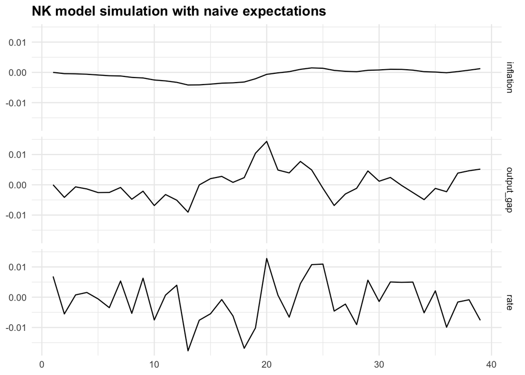

```r
# Solve forward using expectations (perfect foresight)
for(t in 1:(TT-1)){
  y_t <- c(x[t], pi[t])           # current state vector y_t
  E_next <- y_t                   # naive expectations for next period E_t[y_{t+1}] = y_t
  s_t <- c(r_n[t], eps[t])        # exogenous shocks at t
  rhs <- B %*% E_next + C %*% s_t # right-hand side: B E_t[y_{t+1}] + C s_t
  y_next <- solve(A, rhs)         # solve for y_t (A y_t = rhs)
  x[t+1] <- y_next[1]
  pi[t+1] <- y_next[2]
  # policy rate by Taylor rule (observed at t)
  i[t] <- r_n[t] + phi_pi * pi[t] + phi_x * x[t] + eps[t]
}

data.frame(t = 1:(TT-1), output_gap = x[1:(TT-1)], inflation = pi[1:(TT-1)], rate = i[1:(TT-1)]) |>
  pivot_longer(-t, names_to = "variable", values_to = "value") |>
  ggplot(aes(x = t, y = value)) + geom_line() +
  ggtitle("NK model simulation with naive expectations") +
  facet_grid(rows = vars(variable)) +
  theme_minimal() +
  theme(axis.title = element_blank(), title = element_text(face = "bold"))
```